# Assgt Wk 2 RR Course

Bryan K

December 7, 2017

## Activity Monitoring Devices

Read the raw data from a local csv file and add to r. Then set up some values for the code and set up the dates column.

```r
library(dplyr)
library(magrittr)
library(data.table)
library(knitr)
library(kableExtra)
library(lattice)

activity <- read.csv("C:/Users/Bryan/Desktop/DATA SCIENCE CERT/Coursera5_ReproducibleResearch/Ass2/activity.csv", header=TRUE, stringsAsFactors = FALSE)
activity$date <- as.Date(activity$date)

nactivity <- activity  ## Retain NA values for later calculations
activity <- na.omit(activity)  ## Remove NA values for parts 1,2
```

Take the number of steps from the device, gather the total, and return a histogram of the total steps per day. This will then be summarized as a table showing the mean and median for the steps/day:

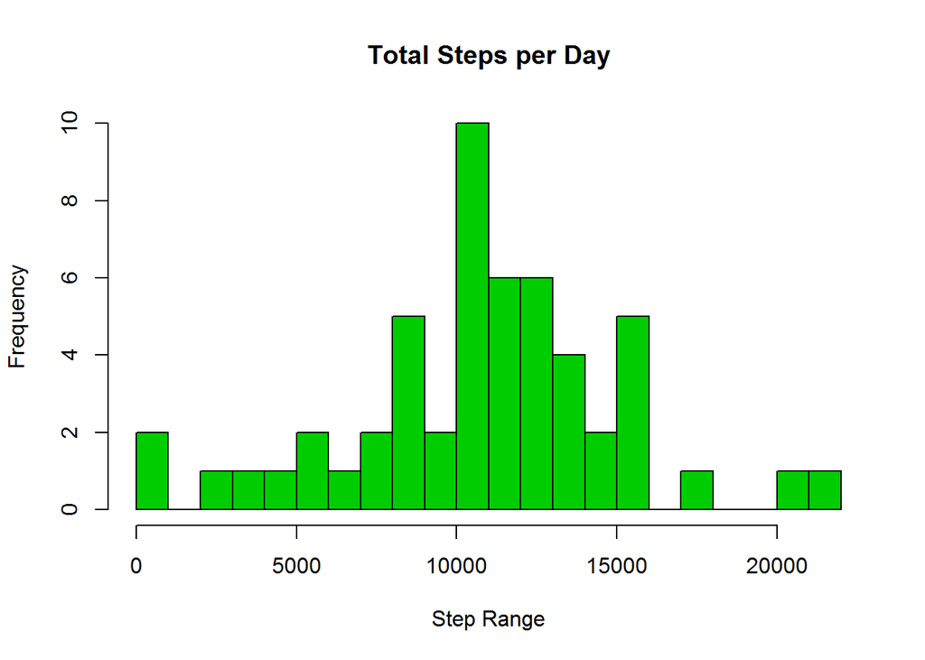

```r
options(digits = 4)
opts_chunk$set(tidy.opts=list(width.cutoff=80),tidy=TRUE)
tot.step <- aggregate(steps ~ date,FUN=sum,data=activity)
tot.step$date <- as.Date(tot.step$date, format="%Y-%m-%d")
names(tot.step) <- c("Date","TotalSteps")

hist(tot.step$TotalSteps,    #Step histogram as Total/day
          main="Total Steps per Day",
          xlab = "Step Range", col = 3,
          breaks=20)
```

```r
# Follow the histogram with statistical summary functions:
mean(tot.step$TotalSteps)
```

```
## [1] 10766
```

```r
median(tot.step$TotalSteps)
```

```
## [1] 10765
```

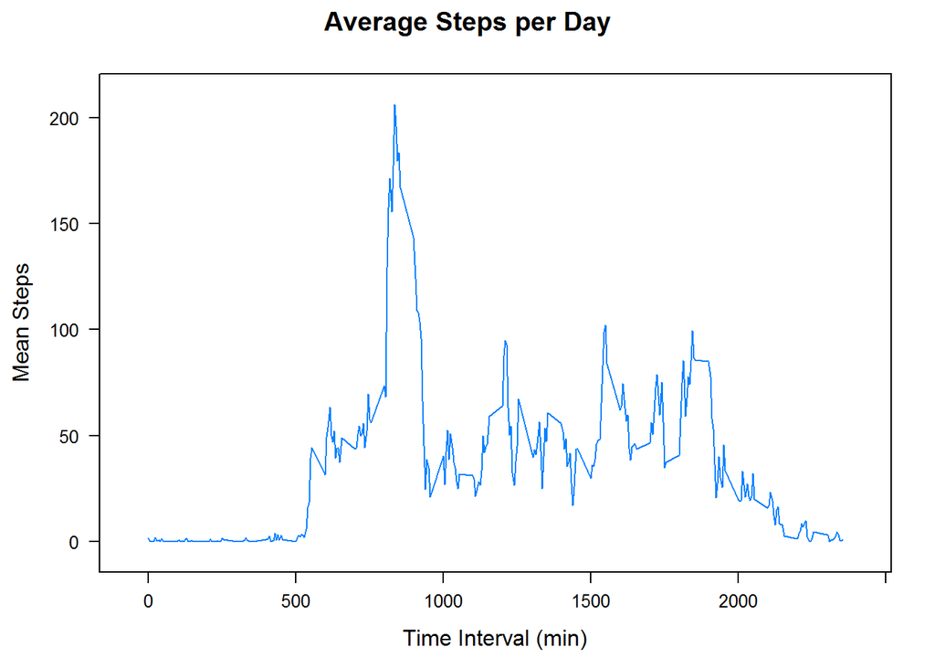

```r
time.step <- as.data.frame(tapply(activity$steps,activity$interval,mean,simplify=FALSE)) # mean calculation
time.step <- cbind(rownames(time.step),time.step)
colnames(time.step) <- c("interval", "mean.step")
rownames(time.step) <- c()
time.step$mean.step <- as.numeric(as.character(time.step$mean.step))
time.step$interval <- as.numeric(as.character(time.step$interval))
xyplot(mean.step~interval, #Generate a time-based xy plot with the interval data
       data=time.step,type = "l",
       main = "Average Steps per Day",
       xlab = "Time Interval (min)", ylab = "Mean Steps",
       scales=list(tck=c(1,0))
       )
```

From this data, we can see that the max avg. steps is 206.1698, which occurs at the interval 835.

We should now take a look at the values that have been left OUT of the data and determine what to do with them. Let’s make a new column counting the NA values in the total data, ‘nactivity’.

```r
nactivity$na_count <- apply(nactivity, 1, function(x) sum(is.na(x)))
```

We now have a new column that effectivly gives a T/F value for NAs which reports a sum of 2304 rows of NA data out of 17568.

To fill in the NA values, we will use the mean for that five-minute interval:

```r
tot.activity <- nactivity
colnames(tot.activity)
```

```
## [1] "steps"    "date"     "interval" "na_count"
```

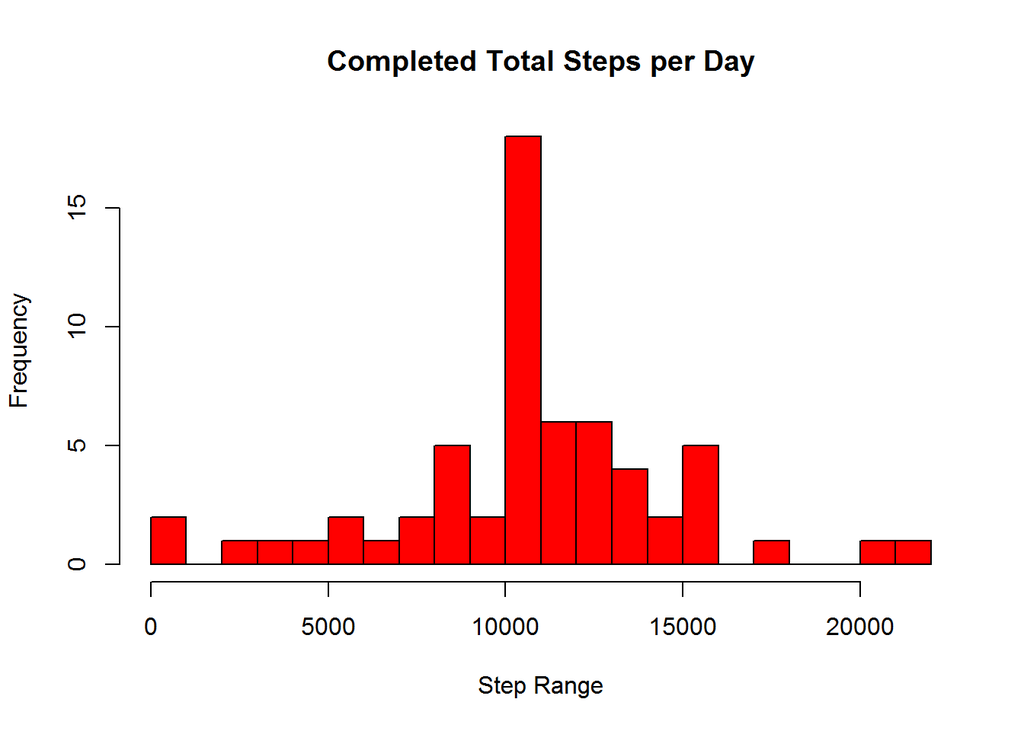

```r
for (i in 1:nrow(tot.activity)) {
      if (is.na(tot.activity$steps[i])) {
            this.step <- as.numeric(time.step$mean.step[which(time.step$interval == tot.activity$interval[i])])
            tot.activity$steps[i] <- this.step
      }
}

tot.step <- aggregate(steps ~ date,FUN=sum,data=tot.activity)
tot.step$date <- as.Date(tot.step$date, format="%Y-%m-%d")
names(tot.step) <- c("Date","TotalSteps")

hist(tot.step$TotalSteps,    #Step histogram as Total/day
          main="Completed Total Steps per Day",
          xlab = "Step Range", col = 2,
          breaks=20)
```

```r
# Follow the histogram with statistical summary functions:
mean(tot.step$TotalSteps)
```

```
## [1] 10766
```

```r
median(tot.step$TotalSteps)
```

```
## [1] 10766
```

It is likely that the steps measured will vary from weekday to weekend. Herein, we shall add columns to the dataset with the weekday and a T/F column determining if it is a weekend.

```r
tot.activity$week <- weekdays(tot.activity$date)
tot.activity$weekend <- tot.activity$week == "Saturday" | tot.activity$week == "Sunday"

# Interval steps for a weekday
time.step.wd <- tapply(tot.activity$steps[which(tot.activity$weekend == FALSE)],
    tot.activity$interval[which(tot.activity$weekend == FALSE)], mean, simplify = FALSE)
time.step.wd <- as.data.frame(time.step.wd)
time.step.wd$weekend <- FALSE
setDT(time.step.wd, keep.rownames = TRUE)[]
```

```
##        rn time.step.wd weekend
##   1:    0        2.251   FALSE
##   2:    5       0.4453   FALSE
##   3:   10       0.1732   FALSE
##   4:   15       0.1979   FALSE
##   5:   20      0.09895   FALSE
##  ---
## 284: 2335        2.249   FALSE
## 285: 2340         2.24   FALSE
## 286: 2345       0.2633   FALSE
## 287: 2350       0.2969   FALSE
## 288: 2355         1.41   FALSE
```

```r
colnames(time.step.wd) <- c("Interval", "Mean", "Weekend")

# Interval steps for a weekend
time.step.we <- tapply(tot.activity$steps[which(tot.activity$weekend == TRUE)], tot.activity$interval[which(tot.activity$weekend ==
    TRUE)], mean, simplify = FALSE)
time.step.we <- as.data.frame(time.step.we)
time.step.we$weekend <- TRUE

setDT(time.step.we, keep.rownames = TRUE)[]
```

```
##        rn time.step.we weekend
##   1:    0       0.2146    TRUE
##   2:    5      0.04245    TRUE
##   3:   10      0.01651    TRUE
##   4:   15      0.01887    TRUE
##   5:   20     0.009434    TRUE
##  ---
## 284: 2335        11.59    TRUE
## 285: 2340        6.288    TRUE
## 286: 2345        1.705    TRUE
## 287: 2350       0.0283    TRUE
## 288: 2355       0.1344    TRUE
```

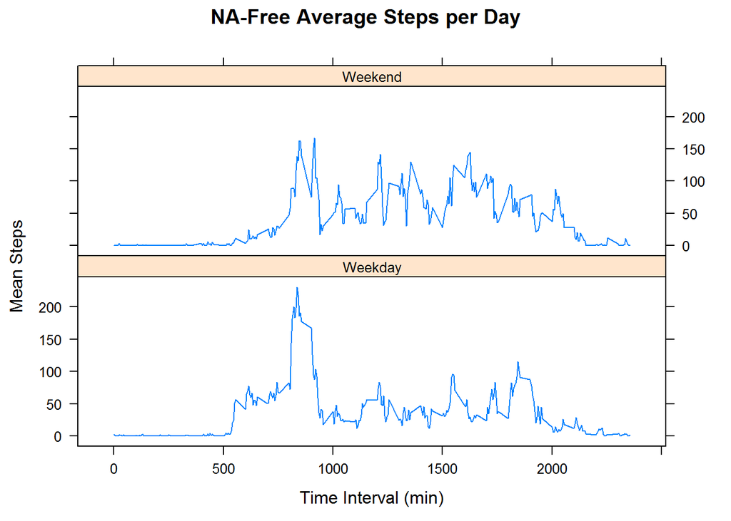

```r
colnames(time.step.we) <- c("Interval", "Mean", "Weekend")

# Generate a numeric table & plot for weekday/weekend, now merged
time.step.week <- rbind(time.step.wd, time.step.we)
colnames(time.step.week) <- c("interval", "mean", "weekend")
time.step.week$mean <- as.numeric(time.step.week$mean)
time.step.week$interval <- as.numeric(time.step.week$interval)

xyplot(mean ~ interval | weekend  # interval vs. mean as a factor of weekend (T/F)
,
    data = time.step.week, type = "l", main = "NA-Free Average Steps per Day", xlab = "Time Interval (min)",
    ylab = "Mean Steps", strip = strip.custom(factor.levels = c("Weekday", "Weekend"),
        par.strip.text = list(cex = 0.8)), layout = c(1, 2))
```